# Preliminary EDA

Tarun Sudhams

11/17/2018

Let’s quickly explore the dimensionality and the behaviors of different categorical features present in the dataset. But before that we will try to import the required libraries for our study.

```r
library(tidyverse)
library(grid)
library(gridExtra)
```

Assigning train and test data to variables.

```r
train = read_csv('train.csv')
test = read_csv('test.csv')
```

```r
head(train)
```

```
## # A tibble: 6 x 143
##   Id      v2a1 hacdor rooms hacapo  v14a refrig  v18q v18q1  r4h1  r4h2
##   <chr>  <dbl>  <int> <int>  <int> <int>  <int> <int> <int> <int> <int>
## 1 ID_2~ 190000      0     3      0     1      1     0    NA     0     1
## 2 ID_f~ 135000      0     4      0     1      1     1     1     0     1
## 3 ID_6~     NA      0     8      0     1      1     0    NA     0     0
## 4 ID_d~ 180000      0     5      0     1      1     1     1     0     2
## 5 ID_d~ 180000      0     5      0     1      1     1     1     0     2
## 6 ID_e~ 180000      0     5      0     1      1     1     1     0     2
## # ... with 132 more variables: r4h3 <int>, r4m1 <int>, r4m2 <int>,
## #   r4m3 <int>, r4t1 <int>, r4t2 <int>, r4t3 <int>, tamhog <int>,
## #   tamviv <int>, escolari <int>, rez_esc <int>, hhsize <int>,
## #   paredblolad <int>, paredzocalo <int>, paredpreb <int>, pareddes <int>,
## #   paredmad <int>, paredzinc <int>, paredfibras <int>, paredother <int>,
## #   pisomoscer <int>, pisocemento <int>, pisoother <int>, pisonatur <int>,
## #   pisonotiene <int>, pisomadera <int>, techozinc <int>,
## #   techoentrepiso <int>, techocane <int>, techootro <int>,
## #   cielorazo <int>, abastaguadentro <int>, abastaguafuera <int>,
## #   abastaguano <int>, public <int>, planpri <int>, noelec <int>,
## #   coopele <int>, sanitario1 <int>, sanitario2 <int>, sanitario3 <int>,
## #   sanitario5 <int>, sanitario6 <int>, energcocinar1 <int>,
## #   energcocinar2 <int>, energcocinar3 <int>, energcocinar4 <int>,
## #   elimbasu1 <int>, elimbasu2 <int>, elimbasu3 <int>, elimbasu4 <int>,
## #   elimbasu5 <int>, elimbasu6 <int>, epared1 <int>, epared2 <int>,
## #   epared3 <int>, etecho1 <int>, etecho2 <int>, etecho3 <int>,
## #   eviv1 <int>, eviv2 <int>, eviv3 <int>, dis <int>, male <int>,
## #   female <int>, estadocivil1 <int>, estadocivil2 <int>,
## #   estadocivil3 <int>, estadocivil4 <int>, estadocivil5 <int>,
## #   estadocivil6 <int>, estadocivil7 <int>, parentesco1 <int>,
## #   parentesco2 <int>, parentesco3 <int>, parentesco4 <int>,
## #   parentesco5 <int>, parentesco6 <int>, parentesco7 <int>,
## #   parentesco8 <int>, parentesco9 <int>, parentesco10 <int>,
## #   parentesco11 <int>, parentesco12 <int>, idhogar <chr>,
## #   hogar_nin <int>, hogar_adul <int>, hogar_mayor <int>,
## #   hogar_total <int>, dependency <chr>, edjefe <chr>, edjefa <chr>,
## #   meaneduc <dbl>, instlevel1 <int>, instlevel2 <int>, instlevel3 <int>,
## #   instlevel4 <int>, instlevel5 <int>, instlevel6 <int>,
## #   instlevel7 <int>, ...
```

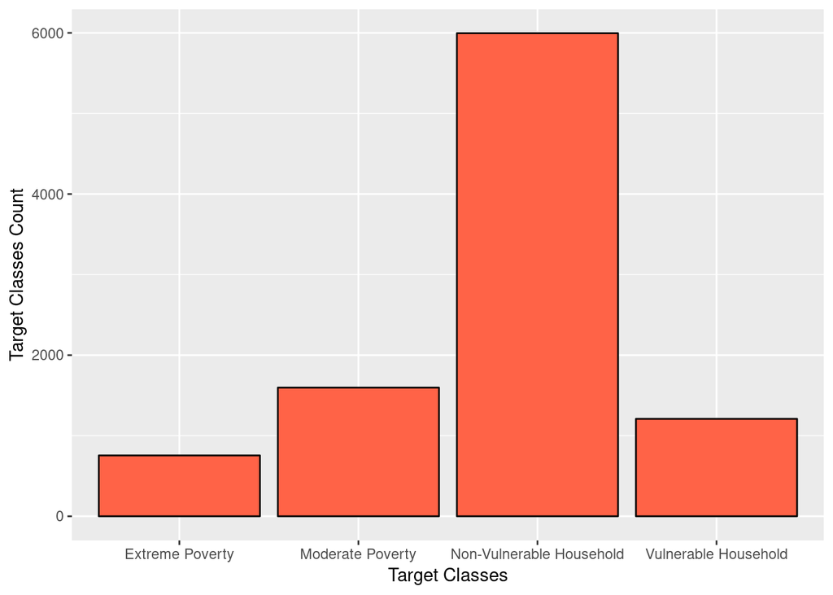

```r
train$Target[train$Target == 1] = 'Extreme Poverty'
train$Target[train$Target == 2] = 'Moderate Poverty'
train$Target[train$Target == 3] = 'Vulnerable Household'
train$Target[train$Target == 4] = 'Non-Vulnerable Household'

train %>%
ggplot(aes(Target))+
geom_bar(color = 'black', fill = 'tomato')+
xlab("Target Classes")+
ylab("Target Classes Count")
```

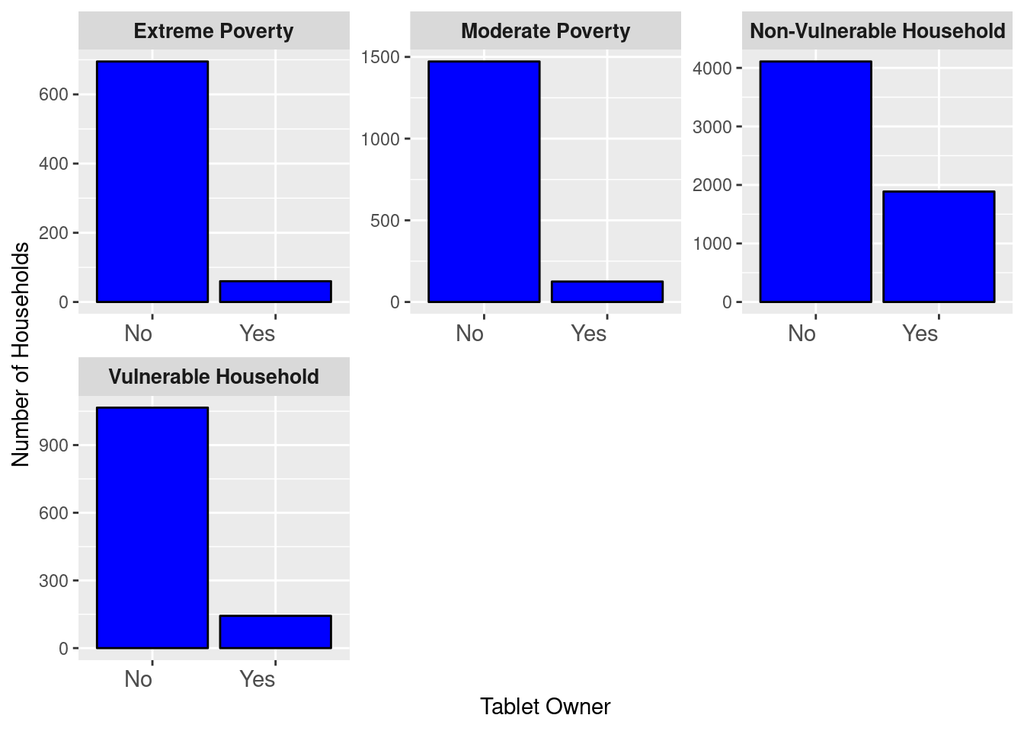

```r
train %>%
ggplot(aes(x = as.factor(v18q)))+
geom_bar(colour = "black", fill = "blue")+
facet_wrap(~Target, scales = "free", ncol = 3)+
theme(axis.text.x = element_text(hjust = 1, size = 11))+
theme(strip.text = element_text(size = 10, face = "bold"))+
labs(x = "Tablet Owner", y = "Number of Households")+
scale_x_discrete(labels = c("No", "Yes"))
```

Majority of the households do not own a tablet but many do. And the interesting thing is that people in extreme poverty households own a tablet! Lets look at how they fare when compared together.

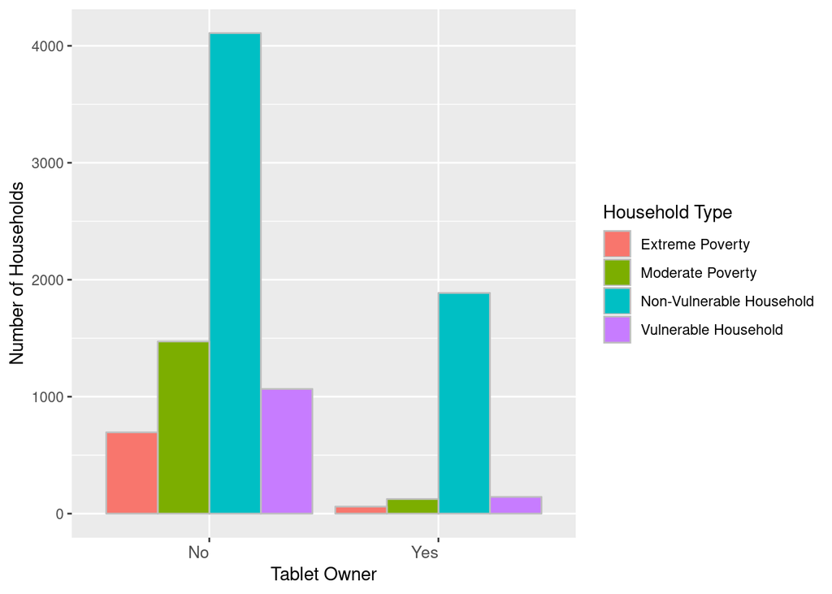

```r
train %>%
ggplot(aes(as.factor(v18q)))+
geom_bar(aes(fill = as.factor(Target)), position = "dodge", color = "grey")+
labs(x = "Tablet Owner", y = "Number of Households")+
guides(fill = guide_legend('Household Type'))+
theme(axis.text.x = element_text(hjust = 1, size = 10))+
scale_x_discrete(labels = c("No", "Yes"))
```

Now lets look at the number of tablets owned by households which do own a tablet

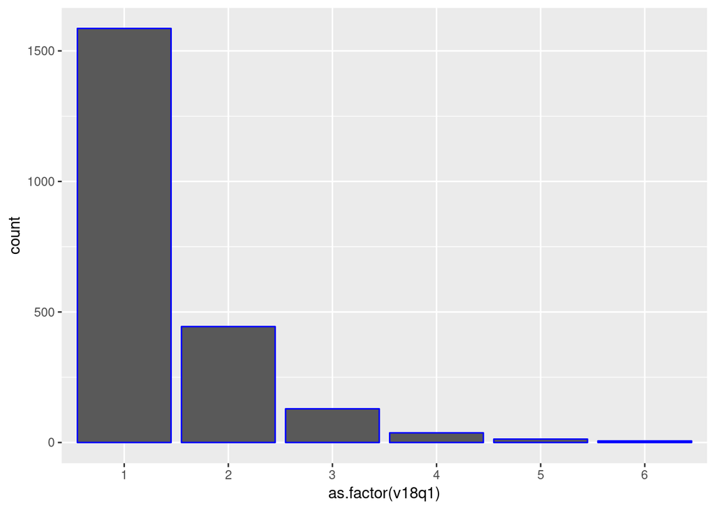

```r
train %>%
filter(!is.na(v18q1)) %>%
ggplot(aes(as.factor(v18q1)))+
geom_bar(color = "blue")
```

So the maximum number of tablets owned is 1 but households do own 6 tablets

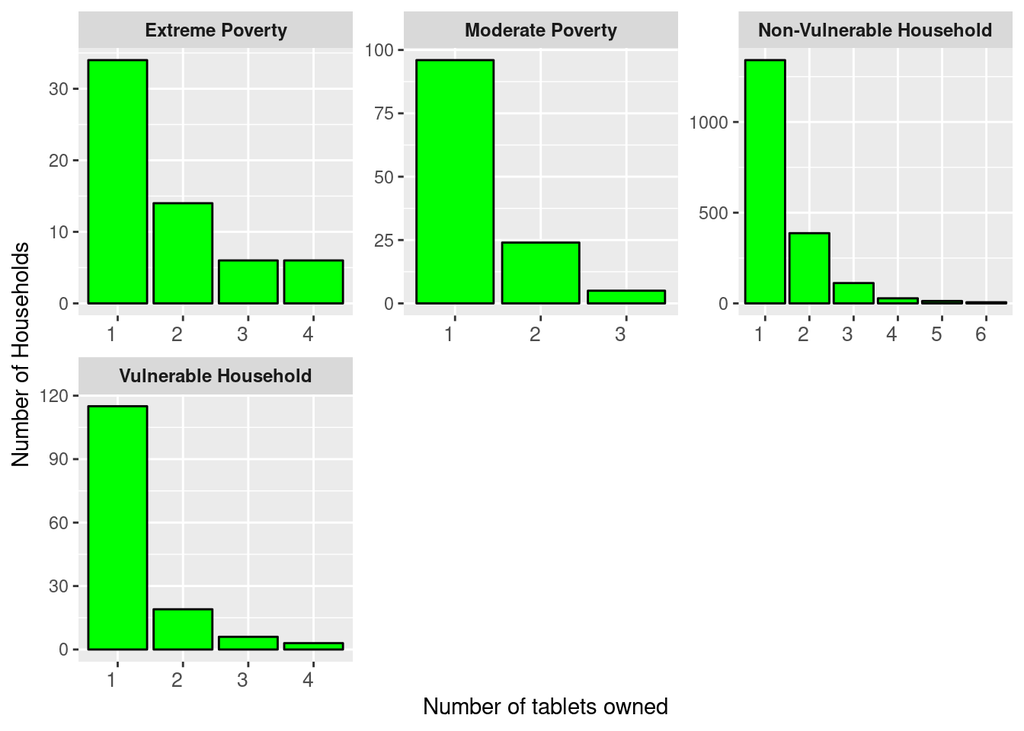

```r
train %>%
filter(!is.na(v18q1)) %>%
ggplot(aes(x = as.factor(v18q1)))+
geom_bar(colour = "black", fill = "green")+
facet_wrap(~Target, scales = "free", ncol = 3)+
theme(axis.text.x = element_text(hjust = 1, size = 10))+
theme(strip.text = element_text(size = 9, face = "bold"))+
labs(x = "Number of tablets owned", y = "Number of Households")
```

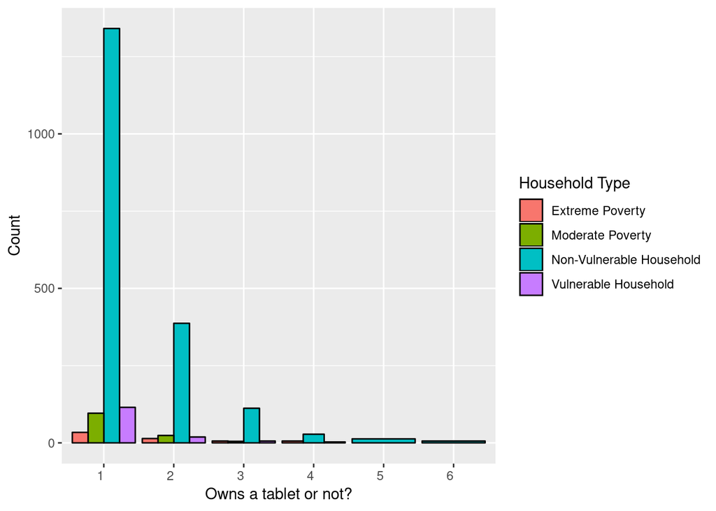

```r
train %>%
filter(!is.na(v18q1)) %>%
ggplot(aes(as.factor(v18q1)))+
geom_bar(aes(fill = as.factor(Target)), position = "dodge", color = "black")+
labs(x = "Owns a tablet or not?", y = "Count")+
guides(fill = guide_legend('Household Type'))+
theme(axis.text.x = element_text(hjust = 1, size = 9))
```

## Male Distribution

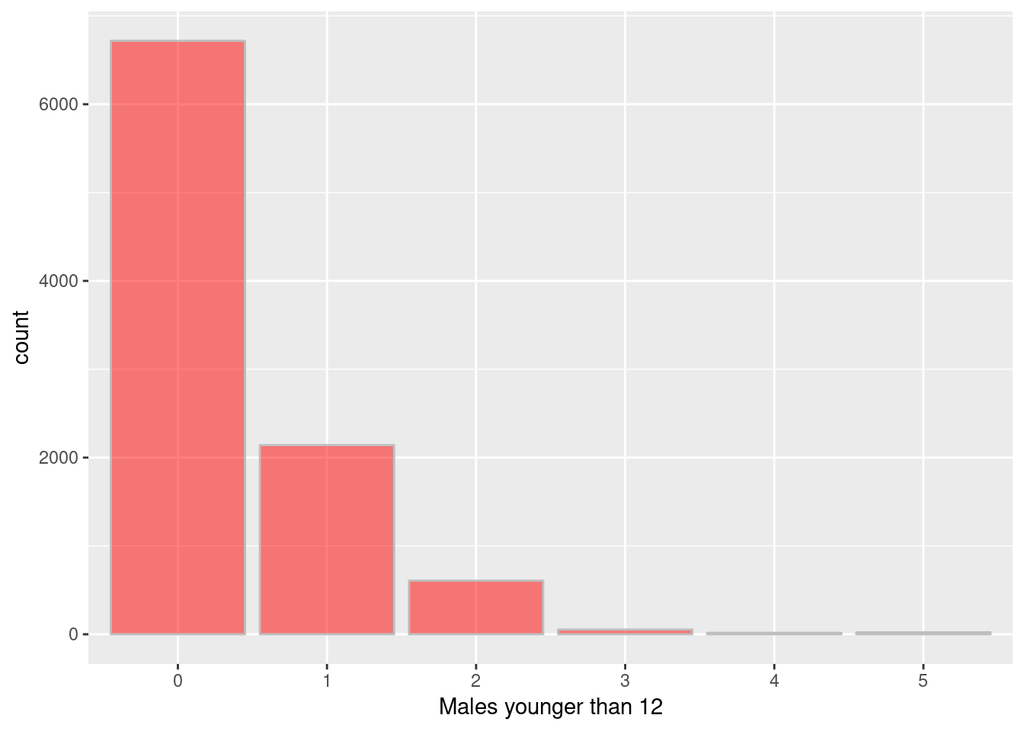

```r
train %>%
ggplot(aes(as.factor(r4h1)))+
geom_bar(color = "grey", fill = "red", alpha = 0.5)+
labs(x = "Males younger than 12", "Number of Households")
```

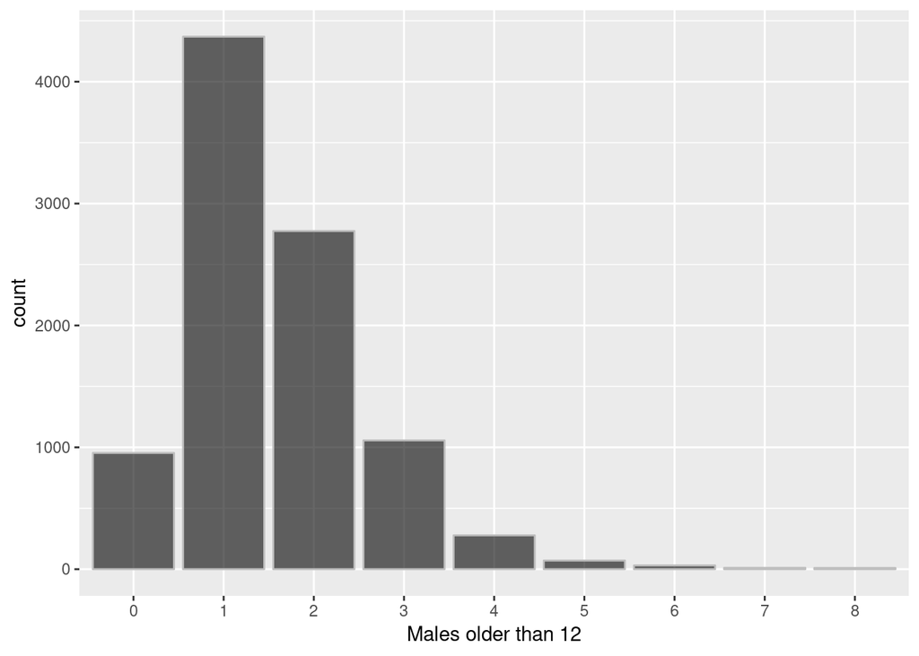

```r
train %>%
ggplot(aes(as.factor(r4h2)))+
geom_bar(color = "grey", fill = "black", alpha = 0.6)+
labs(x = "Males older than 12", "Number of Households")
```

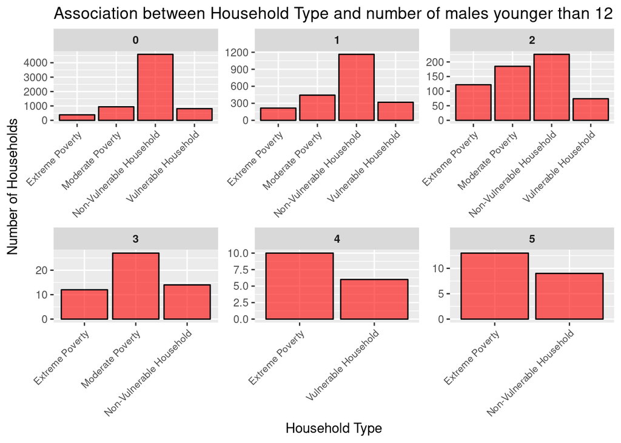

```r
train %>%
ggplot(aes(x = as.factor(Target)))+
geom_bar(colour = "black", fill = "red", alpha = 0.6)+
facet_wrap(~as.factor(r4h1), scales = "free", ncol = 3)+
theme(axis.text.x = element_text(angle = 45, hjust = 1, size = 8))+
theme(strip.text = element_text(size = 9, face = "bold"))+
labs(title = "Association between Household Type and number of males younger than 12", x = "Household Type", y = "Number of Households")
```

We see that the number of males younger than 12 are high in extreme poverty and non-vulnerable households.

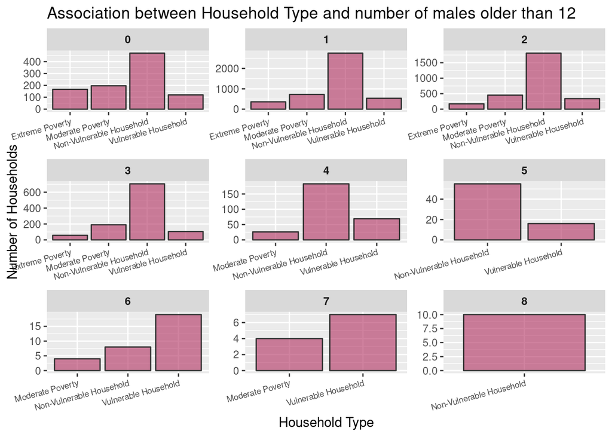

```r
train %>%
ggplot(aes(x = as.factor(Target)))+
geom_bar(colour = "grey19", fill = "maroon", alpha = 0.6)+
facet_wrap(~as.factor(r4h2), scales = "free", ncol = 3)+
theme(axis.text.x = element_text(angle = 15, hjust = 1, size = 7))+
theme(strip.text = element_text(size = 9, face = "bold"))+
labs(title = "Association between Household Type and number of males older than 12 ", x = "Household Type", y = "Number of Households")
```

The number of data points concerning non-vulnerable households is very large. We can remove some datapoints and analyze them to understand the relationship of low income households and compare them

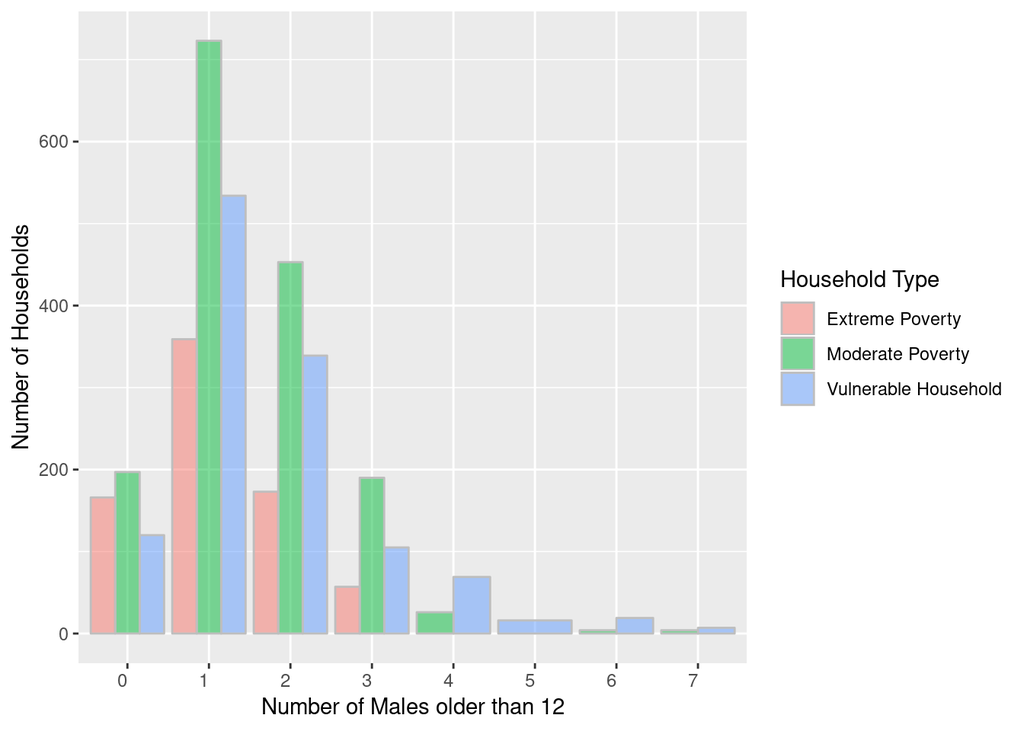

```r
train %>%
filter(Target != "Non-Vulnerable Household") %>%
ggplot(aes(as.factor(r4h2)))+
geom_bar(aes(fill = as.factor(Target)), position = "dodge", color = "grey", alpha = 0.5)+
labs(x = "Number of Males older than 12", y = "Number of Households")+
guides(fill = guide_legend('Household Type'))+
theme(axis.text.x = element_text(hjust = 1, size = 9))
```

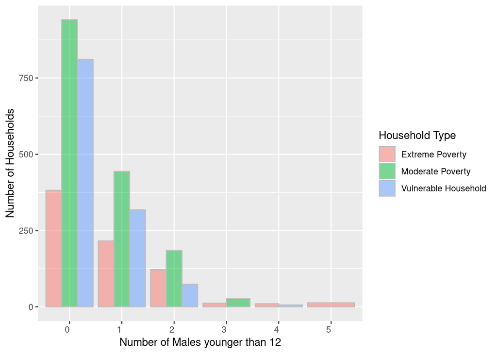

```r
train %>%
filter(Target != "Non-Vulnerable Household") %>%
ggplot(aes(as.factor(r4h1)))+
geom_bar(aes(fill = as.factor(Target)), position = "dodge", color = "grey", alpha = 0.5)+
labs(x = "Number of Males younger than 12", y = "Number of Households")+
guides(fill = guide_legend('Household Type'))+
theme(axis.text.x = element_text(hjust = 1, size = 9))
```

This reveals an interesting property about the extreme poverty household. There is a high population of males younger than 12 in extreme poverty households while the concentration of males older than 12 is lesser.

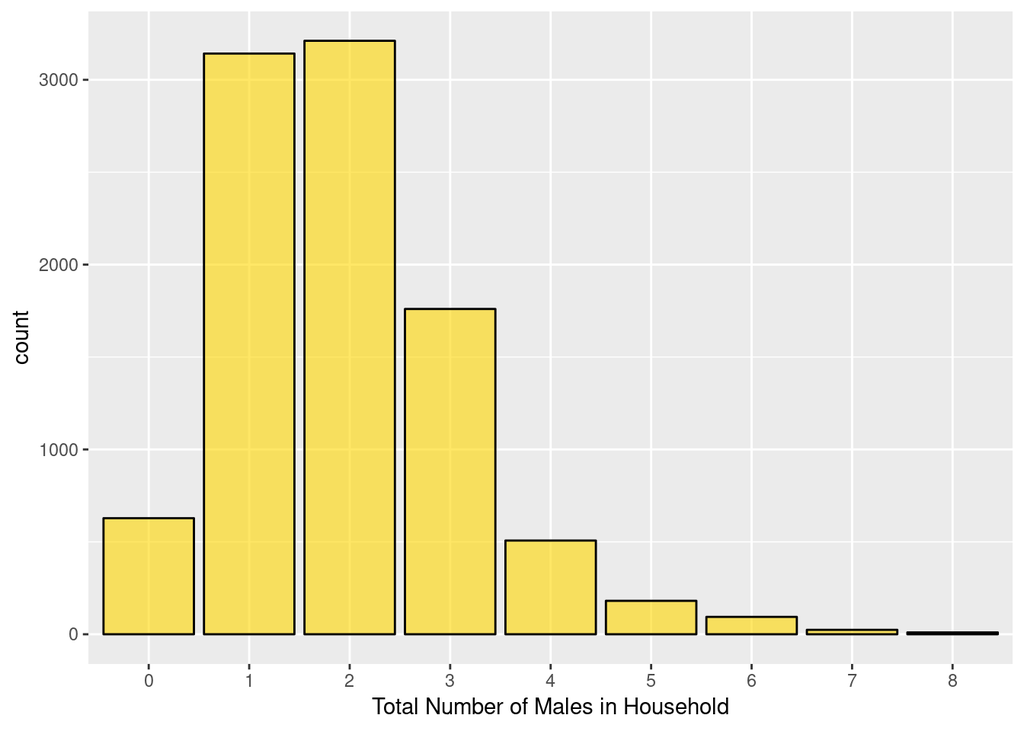

```r
train %>%
ggplot(aes(as.factor(r4h3)))+
geom_bar(color = "black", fill = "gold", alpha = 0.6)+
labs(x = "Total Number of Males in Household", "Number of Households")
```

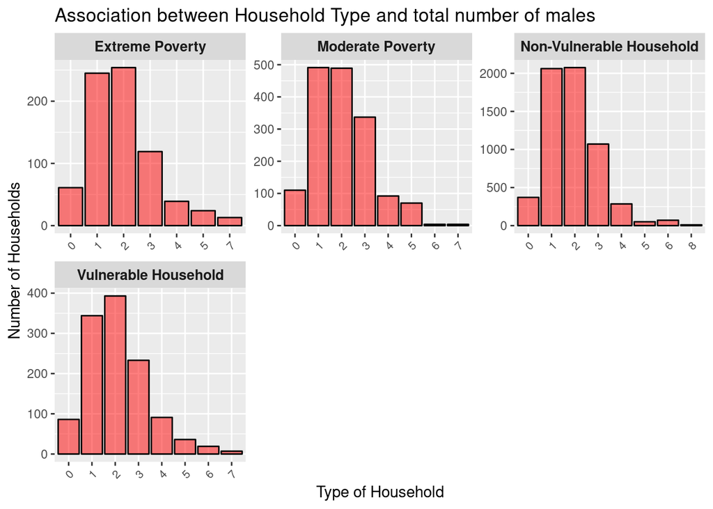

```r
train %>%
ggplot(aes(x = as.factor(r4h3)))+
geom_bar(colour = "black", fill = "red", alpha = 0.5)+
facet_wrap(~as.factor(Target), scales = "free", ncol = 3)+
theme(axis.text.x = element_text(angle = 45, hjust = 1, size = 8))+
theme(strip.text = element_text(face = "bold",size = 10 ))+
labs(title = "Association between Household Type and total number of males", x = "Type of Household", y = "Number of Households")
```

## Female Distribution

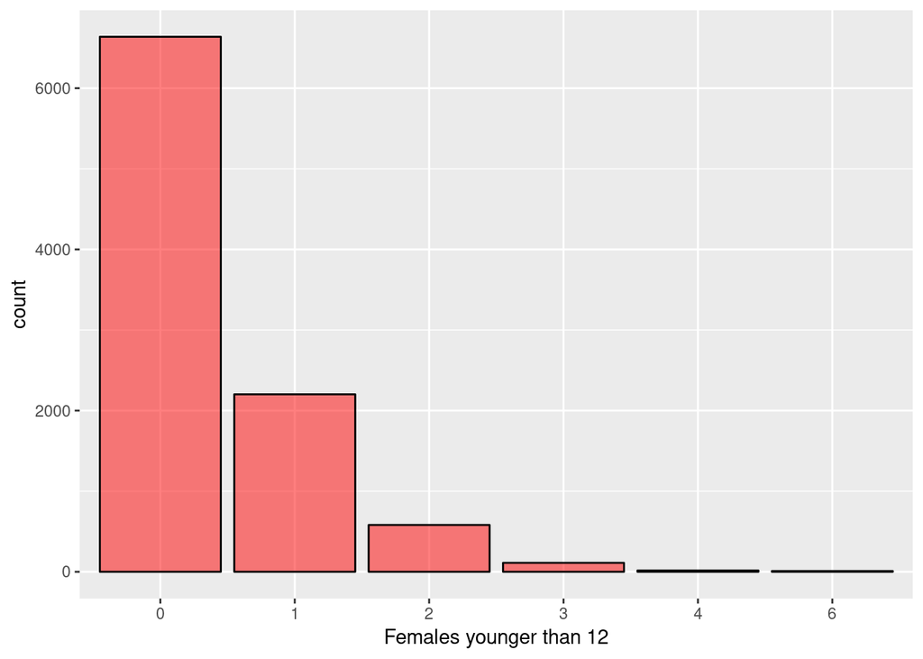

```r
train %>%
ggplot(aes(as.factor(r4m1)))+
geom_bar(color = "black", fill = "red", alpha = 0.5)+
labs(x = "Females younger than 12", "Number of Households")
```

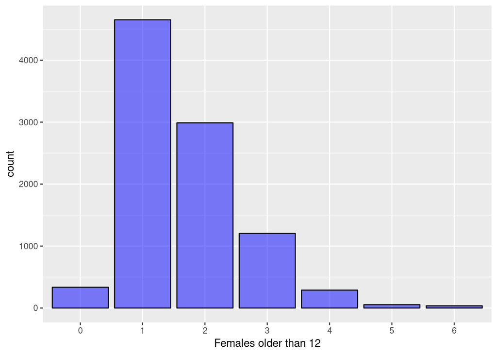

```r
train %>%
ggplot(aes(as.factor(r4m2)))+
geom_bar(color = "black", fill = "blue", alpha = 0.5)+
labs(x = "Females older than 12", "Number of Households")
```

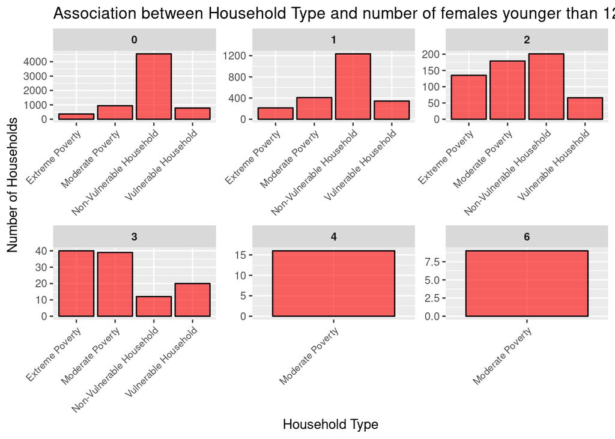

```r
train %>%
ggplot(aes(x = as.factor(Target)))+
geom_bar(colour = "black", fill = "red", alpha = 0.6)+
facet_wrap(~as.factor(r4m1), scales = "free", ncol = 3)+
theme(axis.text.x = element_text(angle = 45, hjust = 1, size = 8))+
theme(strip.text = element_text(size = 9, face = "bold"))+
labs(title = "Association between Household Type and number of females younger than 12", x = "Household Type", y = "Number of Households")
```

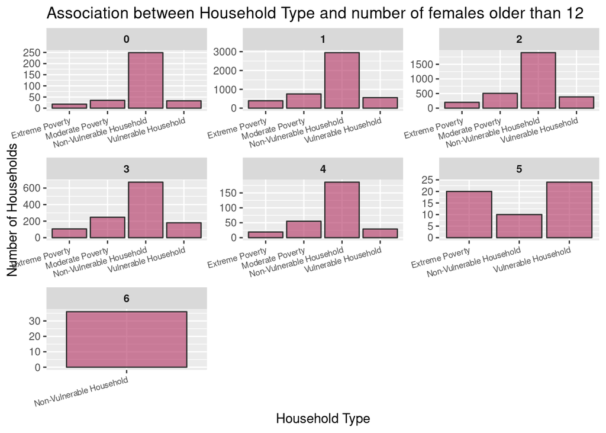

```r
train %>%
ggplot(aes(x = as.factor(Target)))+
geom_bar(colour = "grey19", fill = "maroon", alpha = 0.6)+
facet_wrap(~as.factor(r4m2), scales = "free", ncol = 3)+
theme(axis.text.x = element_text(angle = 15, hjust = 1, size = 7))+
theme(strip.text = element_text(size = 9, face = "bold"))+
labs(title = "Association between Household Type and number of females older than 12", x = "Household Type", y = "Number of Households")
```

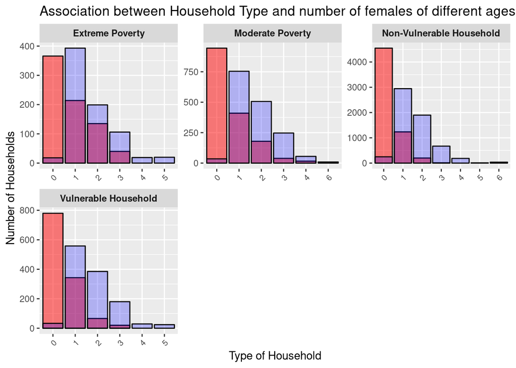

```r
train %>%
ggplot()+
geom_bar(aes(x = as.factor(r4m1)), colour = "black", fill = "red", alpha = 0.5)+
geom_bar(aes(x = as.factor(r4m2)), colour = "black", fill = "blue", alpha = 0.25)+
facet_wrap(~as.factor(Target), scales = "free", ncol = 3)+
theme(axis.text.x = element_text(angle = 45, hjust = 1, size = 8))+
theme(strip.text = element_text(size = 9, face = "bold"))+
labs(title = "Association between Household Type and number of females of different ages", x = "Type of Household", y = "Number of Households")
```

In the above graph, blue corresponds to females older than 12 and red to females younger than 12. There is not a huge population of females younger than 12 in majority of the households. However, the number of females older than 12 are 1 in a majority of the households with the number going upto 5 in households with extreme poverty.

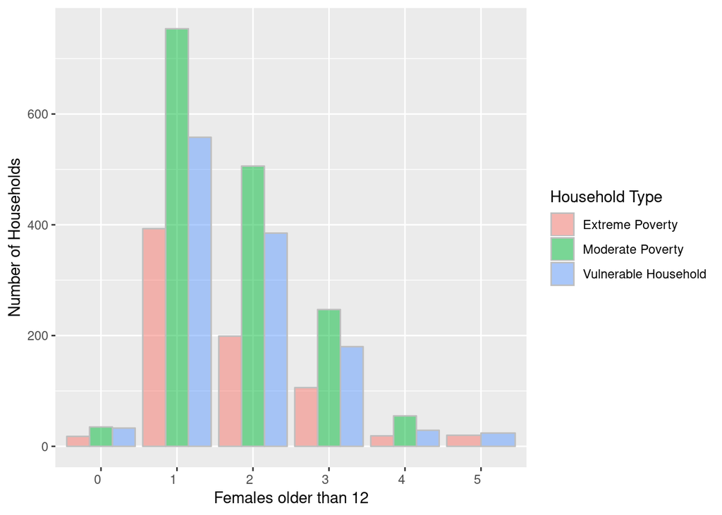

```r
train %>%
filter(Target != "Non-Vulnerable Household") %>%
ggplot(aes(as.factor(r4m2)))+
geom_bar(aes(fill = as.factor(Target)), position = "dodge", color = "grey", alpha = 0.5)+
labs(x = "Females older than 12", y = "Number of Households")+
guides(fill = guide_legend('Household Type'))+
theme(axis.text.x = element_text(hjust = 1, size = 9))
```

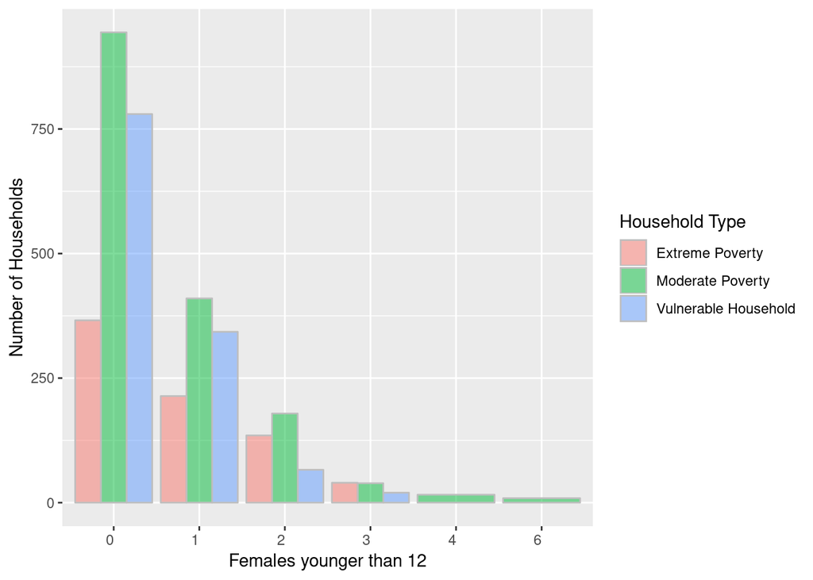

```r
train %>%
filter(Target != "Non-Vulnerable Household") %>%
ggplot(aes(as.factor(r4m1)))+
geom_bar(aes(fill = as.factor(Target)), position = "dodge", color = "grey", alpha = 0.5)+
labs(x = "Females younger than 12", y = "Number of Households")+
guides(fill = guide_legend('Household Type'))+
theme(axis.text.x = element_text(hjust = 1, size = 9))
```

Females younger than 12 seem to be present majorly in moderate poverty households

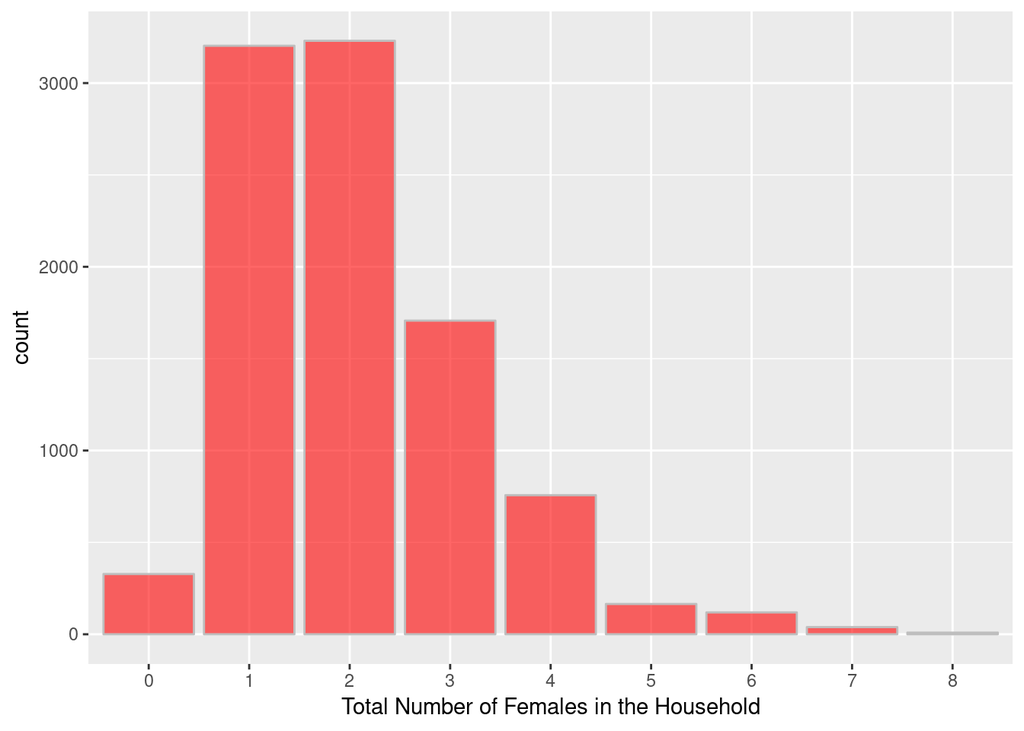

```r
train %>%
ggplot(aes(as.factor(r4m3)))+
geom_bar(color = "grey", fill = "red", alpha = 0.6)+
labs(x = "Total Number of Females in the Household", "Number of Households")
```

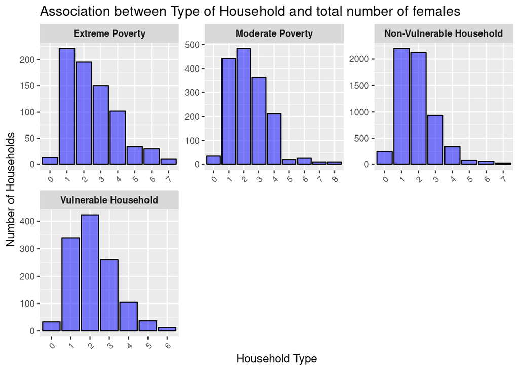

```r
train %>%
ggplot(aes(x = as.factor(r4m3)))+
geom_bar(colour = "black", fill = "blue", alpha = 0.5)+
facet_wrap(~as.factor(Target), scales = "free", ncol = 3)+
theme(axis.text.x = element_text(angle = 45, size = 8, hjust = 1))+
theme(strip.text = element_text(size = 9, face = "bold"))+
labs(title = "Association between Type of Household and total number of females ", x = "Household Type", y = "Number of Households")
```

## Person Distribution

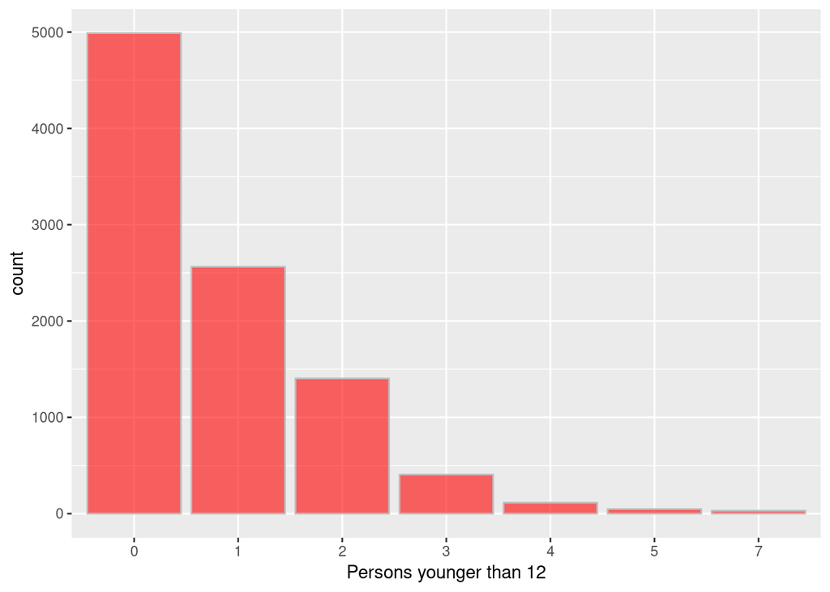

```r
train %>%
ggplot(aes(as.factor(r4t1)))+
geom_bar(color = "grey", fill = "red", alpha = 0.6)+
labs(x = "Persons younger than 12", "Number of Households")
```

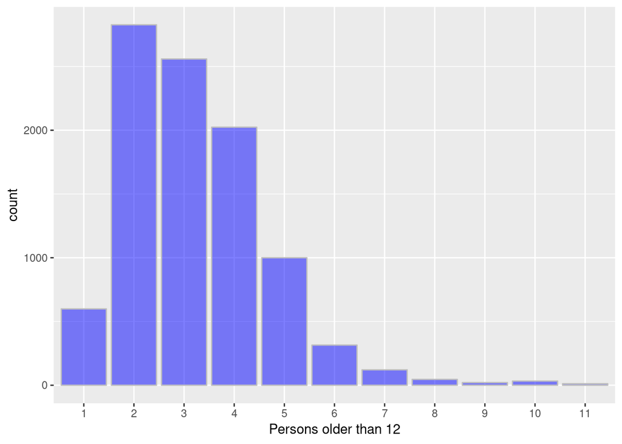

```r
train %>%
ggplot(aes(as.factor(r4t2)))+
geom_bar(color = "grey", fill = "blue", alpha = 0.5)+
labs(x = "Persons older than 12", "Number of Households")
```

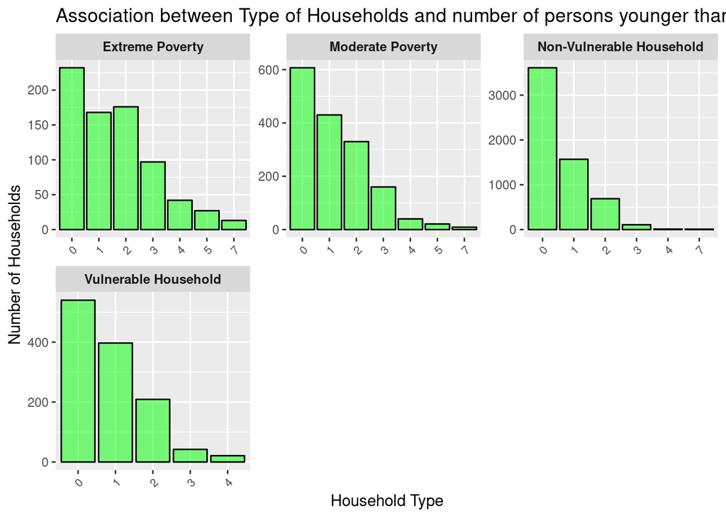

```r
train %>%
ggplot()+
geom_bar(aes(as.factor(r4t1)), colour = "black", fill = "green", alpha = 0.5)+
facet_wrap(~as.factor(Target), scales = "free", ncol = 3)+
theme(axis.text.x = element_text(angle = 45, hjust = 1, size = 8))+
theme(strip.text = element_text(size = 9, face = "bold"))+
labs(title = "Association between Type of Households and number of persons younger than 12 ", x = "Household Type", y = "Number of Households")
```

Moderate poverty and extreme poverty households have a huge number of persons younger than 12 whereas vulnerable and non-vulnerable households have a lesser number of persons age less than 12.

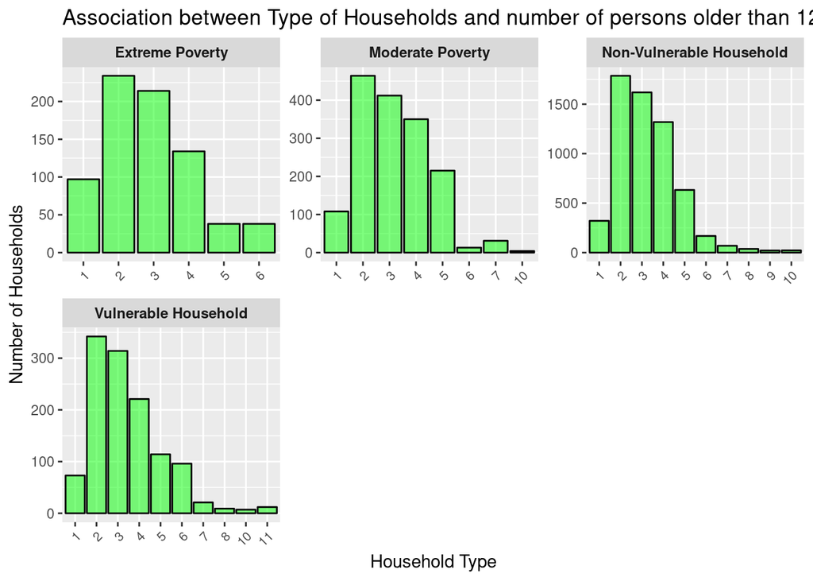

```r
train %>%
ggplot()+
geom_bar(aes(as.factor(r4t2)), colour = "black", fill = "green", alpha = 0.5)+
facet_wrap(~as.factor(Target), scales = "free", ncol = 3)+
theme(axis.text.x = element_text(angle = 45, hjust = 1, size = 8))+
theme(strip.text = element_text(size = 9, face = "bold"))+
labs(title = "Association between Type of Households and number of persons older than 12 ", x = "Household Type", y = "Number of Households")
```

There is a reversal of results here with the number of persons older than 12 being higher in non-vulnerable and vulnerable households.

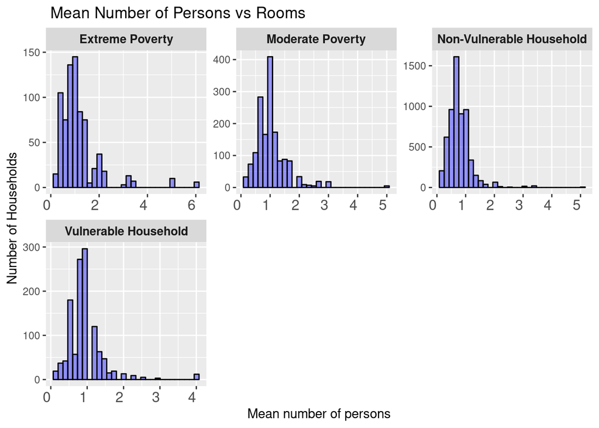

```r
train %>%
mutate(
    mean = r4t3/rooms
) %>%
ggplot(aes(x = mean))+
geom_histogram(colour = "black", fill = "blue", bins = 30, alpha = 0.4)+
facet_wrap(~Target, scales = "free", ncol = 3)+
theme(axis.text.x = element_text(hjust = 1, size = 12))+
theme(strip.text = element_text(face = "bold", size = 10))+
labs(title =" Mean Number of Persons vs Rooms", x = "Mean number of persons", y = "Number of Households", size = 12)
```

The number of persons in a room goes up as the households get poorer.

## Number of Years of Schooling

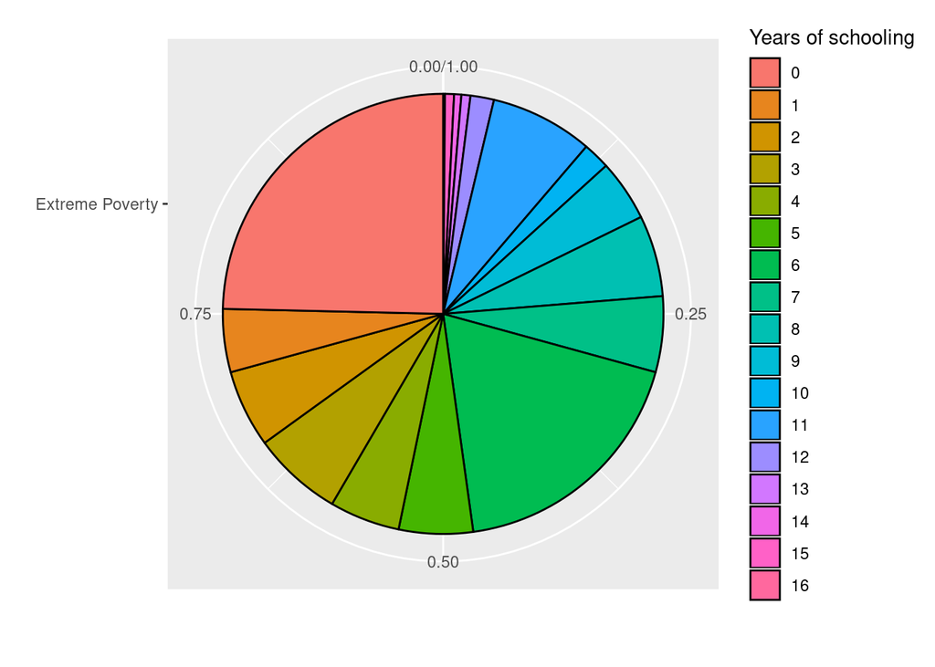

```r
train %>%
filter(Target == "Extreme Poverty") %>%
ggplot(aes(x = as.factor(Target), stat = 'bin', fill = as.factor(escolari)))+
geom_bar(position = 'fill', color = 'black')+
coord_polar("y")+
labs(x = "", y = "")+
guides(fill = guide_legend("Years of schooling"))
```

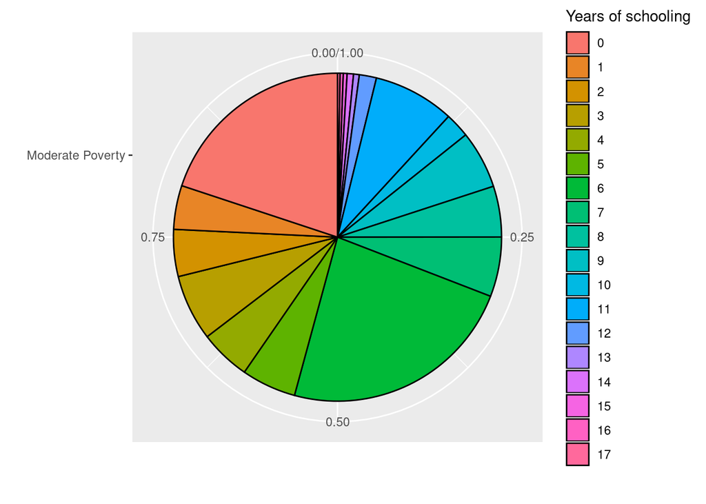

```r
train %>%
filter(Target == "Moderate Poverty") %>%
ggplot(aes(x = as.factor(Target), stat = 'bin', fill = as.factor(escolari)))+
geom_bar(position = 'fill', color = 'black')+
coord_polar("y")+
labs(x = "", y = "")+
guides(fill = guide_legend("Years of schooling"))
```

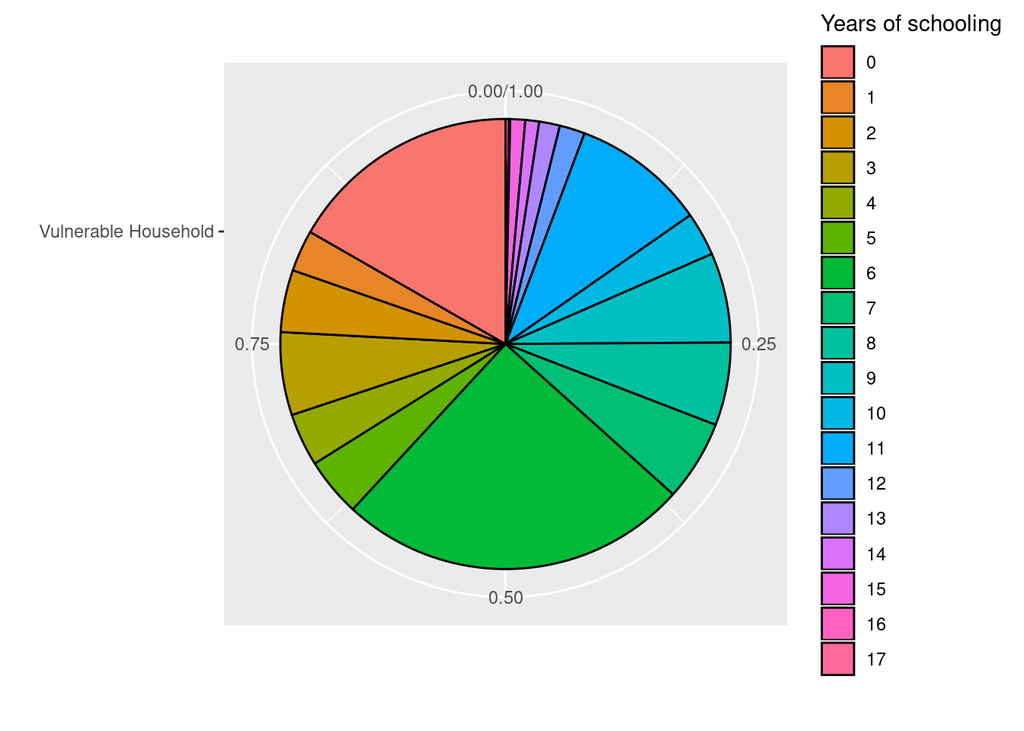

```r
train %>%
filter(Target == "Vulnerable Household") %>%
ggplot(aes(x = as.factor(Target), stat = 'bin', fill = as.factor(escolari)))+
geom_bar(position = 'fill', color = 'black')+
coord_polar("y")+
labs(x = "", y = "")+
guides(fill = guide_legend("Years of schooling"))
```

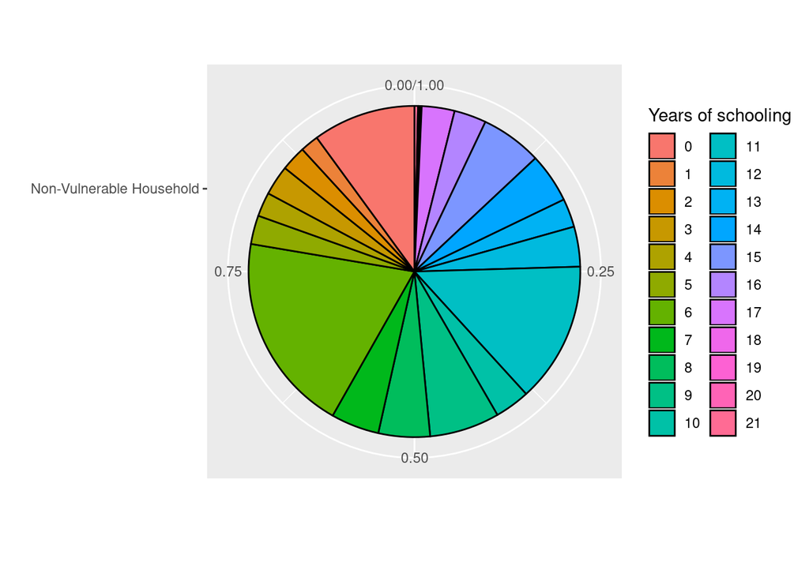

```r
train %>%
filter(Target == "Non-Vulnerable Household") %>%
ggplot(aes(x = as.factor(Target), stat = 'bin', fill = as.factor(escolari)))+
geom_bar(position = 'fill', color = 'black')+
coord_polar("y")+
labs(x = "", y = "")+
guides(fill = guide_legend("Years of schooling"))
```